# SQL Quiz 201

Intermediate SQL interview assessment by RJET Finance Analytics

**1) Times and Totals**

Imagine we have a table called purchases with purchase IDs, amounts, and times the purchase were made. Let’s say it looks like this:

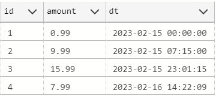

```
SELECT
    SUM(amount) AS sum
FROM purchases
WHERE
    dt = '2023-02-15'
```

*Answer*  
What happened? There were three purchases made on Feb 15: IDs 1, 2, and 3. The sum should therefore be $26.97. Instead, only the first purchase was counted.

**2) Which SQL statement will not generate any error message?**

A. SELECT * FROM EMP WHERE EMPNO LIKE (1,2,3,4)

B. SELECT * FROM EMP WHERE SAL BETWEEN 3000 TO 15000

C. SELECT * FROM EMP WHERE COMM IS NOT NULL

D. All of the above

**3) To specify a list of values ______ Operator is used?**

A. IN

B. Like

C. Between

D. IS

**4) Which statement is valid?**

A. ALTER TABLE EMPLOYEE MODIFY (last_name CHAR2(2000))

B. ALTER TABLE EMPLOYEE CHANGE (last_name CHAR2(2000))

C. ALTER TABLE EMPLOYEE CHANGE (last_name VARCHAR2 (2000))

D. ALTER TABLE EMPLOYEE MODIFY (last_name VARCHAR2 (2000))

**5) How can you insert a new row into the “STORE” table?**

A. INSERT ROW (1,‟WHITNEY BRYANT‟) INTO STORE

B. INSERT VALUES (1,‟WHITNEY BRYANT‟) INTO STORE

C. INSERT INTO (1,‟WHITNEY BRYANT‟) STORE

D. INSERT INTO STORE VALUES (1,‟WHITNEY BRYANT‟)

**6) Which is a valid CREATE TABLE statement?**

A. Create table emp add(id integer(3))

B. Create table emp (id integers(3))

C. Create table emp modified (id integer(3))

D. Create table emp (id integer(3))

Be prepared to explain your answer to any of the multiple choice questions.